# Medidas de tendencia central

[Valdez Fonseca Jorge Diego](https://diiegood.github.io)

Estadística 2022-2, [Facultad de economía](http://www.economia.unam.mx/)

2/3/2022

### 1. ¿Qué son las medidas de tendencia central? 🤔

> “Son medidas estadísticas que se usan para describir como se puede resumir la localización de los datos. Ubican e identifican el punto alrededor del cual se centran los datos. Las medidas de tendencia central nos indican hacia donde se inclinan o se agrupan más los datos. Las más utilizadas son: la media, la mediana y la moda.”

[UAEH(2022)](https://www.uaeh.edu.mx/division_academica/educacion-media/repositorio/2010/6-semestre/estadistica/medidas-tendencia-central.pdf)

Para este ejemplo, pri mero generaremos una serie de **100** números aleatorios entre **1** y **20** mediante la función `sample`. El argumento `TRUE` nos permitirá generar una muestra con remplazo:

```r
numeros <- sample(1:20, 100, TRUE)
numeros
```

```
##   [1]  4 11 12  9 17 10  7 14 15 14  3 18 19  3 13 18 20 10 11 19  8  5 14  7  1
##  [26] 13  2 11  1  3 13  6  1 12 14  3 14 13 12 13 11 10  2 14 13  8 14  7 13  9
##  [51] 20 10  8 14  3  9 17  8  1  3 19  9 20 14  3 11  3 12 18  1 10 19 15  2  5
##  [76] 16 10 14  4  2  2 20 16  2 11 10  4  8 18  4 20 17 16 20 19  4  1 17  5 19
```

### 2. Mediana 📍

Para obtener la **mediana**, podemos ordenar los `numeros` de menor a mayor, **el número que esté en medio de la muestra será la mediana**. Si utilizamos R, se puede hacer el cálculo de la **mediana** con la función `median`:

```r
mediana <- median(numeros)
mediana
```

```
## [1] 11
```

### 3. Media 🧮

$$Media ={\frac {1}{n}}\sum _{i=1}^{n}a_{i}={\frac {a_{1}+a_{2}+\cdots +a_{n}}{n}}$$

Si usamos R, podemos obtener la media de una muestra si utlilizamos la función **mean**:

```r
media <- mean(numeros)
media
```

```
## [1] 10.47
```

### 4. Moda 📊

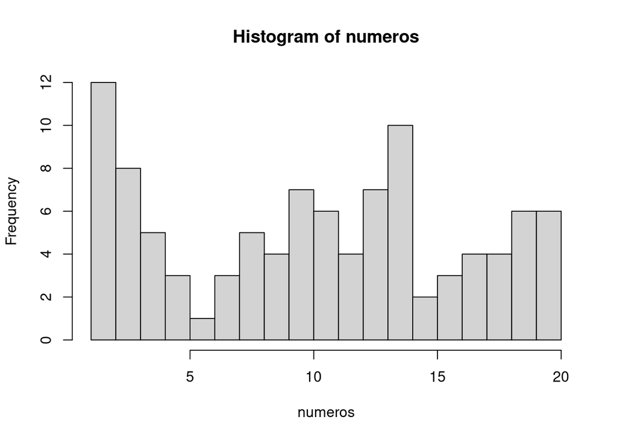

```r
# El argumento breaks nos permite dividir en histograma en las partes que queramos
hist(numeros, breaks = 20)
```

Para obtener un resultado con más precisión, podemos obtener la **moda** si generamos una **tabla de frecuencias** con la función `table` y la función `data.frame`, **aquel elemento con mayor frecuencia será la moda**:

```r
tabla.frecuencias <- data.frame(table(numeros))
tabla.frecuencias
```

```
##    numeros Freq
## 1        1    6
## 2        2    6
## 3        3    8
## 4        4    5
## 5        5    3
## 6        6    1
## 7        7    3
## 8        8    5
## 9        9    4
## 10      10    7
## 11      11    6
## 12      12    4
## 13      13    7
## 14      14   10
## 15      15    2
## 16      16    3
## 17      17    4
## 18      18    4
## 19      19    6
## 20      20    6
```

### 5. Ejercicio 👩‍💻👨‍💻✍

Aplica lo que aprendiste, obten la **mediana**, **media** y **moda** de la siguiente muestra de números:

```r
# Con la función seq, creamos una secuencia de 1 a 10 en intervalos de 0.1 en 0.1
secuencia <- seq(1, 10, 0.1)
muestra <- sample(secuencia, 100, TRUE)
muestra
```

```
##   [1]  9.4  5.2  6.2  9.1  3.2  4.6  3.5  7.7  8.1  8.5  4.5  5.3  3.3  9.2  8.8
##  [16]  4.7  8.6  7.7  6.0  5.5  5.1  8.6  8.8  5.5  1.1  5.4  1.8  3.1  2.4  6.3
##  [31]  7.9  6.6  9.8  1.8  3.9  5.3  9.5  3.9  1.9  7.5  4.7  4.2  3.1  7.8  2.5
##  [46]  5.9  5.4  9.1  7.0  4.8  9.3  8.7 10.0  4.1  1.1  1.6  2.6  2.5  7.0  9.1
##  [61]  7.5  7.6  4.8  8.8  8.7  6.0  2.4  7.7  6.9  3.0  7.5  4.7  6.0  7.5  5.4
##  [76]  4.4  7.6  6.3  7.3  7.1  1.5  2.4  3.3  9.3  2.3  5.4  6.0  8.8  2.1  6.9
##  [91]  1.9  9.2  2.3  8.0  4.9  8.7  6.2  8.5  4.6  1.6
```

##### Mediana

```r
# Aquí el cálculo de la mediana
```

##### Media

```r
# Aquí el cálculo de la media
```

##### Moda

```r
# Aquí el cálculo de la moda
```

💻[Código disponible en RStudio Cloud](https://rstudio.cloud/project/3671022)💻